# HW7_Porter_Erica

# Problem 1

I created a new repository with the name EMP_Stats under my username, ericamp. The link to my new repository is https://github.com/ericamp/EMP_Stats

# Problem 2: Sum of Squares

The objective of this problem is to calculate sums of squares four different ways.

For loop: calculate sum of squares with the same natural process as the formula $S_{xx} = \sum_{i=1}^{n} (x_{i}-\bar{x})^{2} = \sum_{i=1}^{n} x_{i}^{2} - \frac{(\sum_{i=1}^{n} x_{i})^{2}}{n}$

Vector operations: use the same process as the for loop, replacing exponentiation with the %*% operator, eliminating the need for indices to iterate on.

Foreach: parallelize the sum of squares calculation with $\texttt{foreach}$; works very similarly to the for loop, but the $\texttt{foreach}$ command tabkes both $\texttt{.combine}$ and an index.

parSapply: write a function and pass this to $\texttt{parSapply}$ to perform a set number of times without need for an index.

Below are the parallelized sum of squares operations that were not included/requested in HW6.

```r
# Part C: %dopar% calculation

c1 <- makeCluster(2)
registerDoParallel(c1)
time3 <- system.time({
    SS1 <- foreach(i = 1:n, .combine = "+") %dopar% {
        (y[i] - y_avg)^2
    }
})

stopCluster(c1)

# Part D: parSapply calculation

sum_fun <- function(y) {
    ((y - y_avg)^2)
}

cluster2 <- makeCluster(2)
registerDoParallel(cluster2)
clusterExport(cluster2, c("sum_fun", "y_avg"))
time4 <- system.time({
    SS2 <- sum(parSapply(cluster2, 1:n, function(y) sum_fun(y)))

})
stopCluster(cluster2)
```

| Method | SST calculation | Elapsed | System | User |
| --- | --- | --- | --- | --- |
| for loop | 100062.78244576 | 0.0169999999999999 | 0 | 0.0170000000000001 |
| vector | 100062.78244576 | 0.002 | 0.001 | 0.002 |
| foreach | 100062.78244576 | 38.768 | 2.206 | 35.437 |
| parSapply | 333328325183168 | 0.209000000000003 | 0.00700000000000012 | 0.0670000000000002 |

# Problem 3: Gradient Descent

The inputs that we define/intitialize are tolerance, alpha, and the initial $\Theta$ matrix, so it seems best to parallelize based upon one of these values (e.g. different possible $\alpha$’s, different possible $\Theta$’s).

```r
# Problem 3: parallelize matrix

# Wrapping around process I used last homework
first_theta <- matrix(0, nrow = 2)
alpha = 0.01
tol = 0.01
m <- length(h)

# changing alpha seems easier, although potentially unhelpful
ca <- makeCluster(2)
registerDoParallel(ca)
alpha_vec <- seq(0, 0.1, 0.01)
foreach(a = 1:11, .combine = "c") %dopar% {
    alpha <- alpha_vec[a]
    for (i in 1:m) {
        while (abs(theta[2] - first_theta[2]) > tol && abs(theta[1] -
            first_theta[1]) > tol) {

            first_theta[1] <- theta[1] - (alpha * (1/m)) * sum(first_theta[1] +
                first_theta[2] * X[i, 2] - h[i])
            first_theta[2] <- theta[2] - (alpha * (1/m)) * sum((theta[1] +
                theta[2] * X[i, 2] - h[i]) * X[i, 2])

        }
    }
}
```

```r
stopCluster(ca)

# can also attempt to parallelize through different initial
# theta values

tseq <- matrix(c(rep(0, 10), seq(0, 1, by = 0.1)), nrow = 2,
    ncol = 10, byrow = T)
cb <- makeCluster(2)
registerDoParallel(cb)
result_grad <- foreach(j = 1:10, .combine = "c") %dopar% {
    first_theta[] <- tseq[j]
    for (i in 1:m) {
        while (abs(theta[2] - first_theta[2]) > tol && abs(theta[1] -
            first_theta[1]) > tol) {

            first_theta[1] <- theta[1] - (alpha * (1/m)) * sum(first_theta[1] +
                first_theta[2] * X[i, 2] - h[i])
            first_theta[2] <- theta[2] - (alpha * (1/m)) * sum((theta[1] +
                theta[2] * X[i, 2] - h[i]) * X[i, 2])

        }
    }
}
stopCluster(cb)
```

# Problem 4: Boostrap

Use $\texttt{foreach}$ to perform Boostrap on the given X and Y matrices and provide summary statistics for the resulting $\hat{\beta}^{(b)}$ values.

After inputing the given data, I did the following with $\texttt{foreach}$ and $\texttt{%dorng%}$.

```r
beta_boot <- matrix(NA, nrow = 10000, ncol = 4)
index_boot <- matrix(0, nrow = n, ncol = 1)
boot_result <- list()

c4 <- makeCluster(2)
registerDoParallel(c4)
registerDoRNG()
set.seed(1267)

boot_result <- foreach(b = 1:10000, .combine = "rbind") %dorng%
    {
        index_boot <- sample(1:n, n, replace = TRUE)
        X_boot <- X[index_boot, ]
        Y_boot <- Y[index_boot]
        beta_boot <- coef(lm(Y_boot ~ 0 + X_boot))
        return(beta_boot)
    }

stopCluster(c4)
```

|  | X_boot1 | X_boot2 | X_boot3 | X_boot4 |
| --- | --- | --- | --- | --- |
|  | Min. :0.4403 | Min. :1.756 | Min. :2.894 | Min. :-0.117579 |
|  | 1st Qu.:1.2329 | 1st Qu.:2.022 | 1st Qu.:3.032 | 1st Qu.: 0.009059 |
|  | Median :1.3888 | Median :2.046 | Median :3.053 | Median : 0.012311 |
|  | Mean :1.3893 | Mean :2.039 | Mean :3.054 | Mean : 0.016172 |
|  | 3rd Qu.:1.5458 | 3rd Qu.:2.066 | 3rd Qu.:3.075 | 3rd Qu.: 0.019435 |
|  | Max. :2.3760 | Max. :2.322 | Max. :3.218 | Max. : 0.144974 |

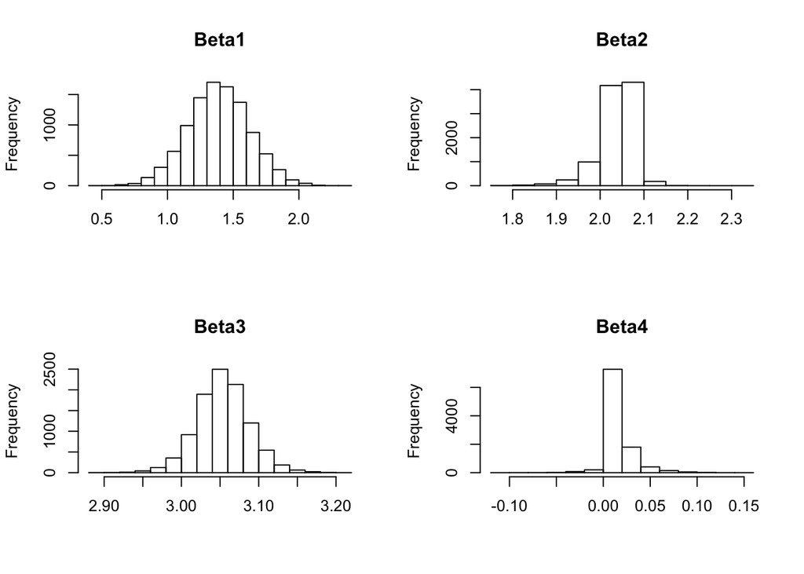

# Appendix

```r
knitr::opts_chunk$set(echo = TRUE, fig.pos = "h")
library(stargazer)
library(data.table)
library(lubridate)
library(lintr)
library(data.table)
library(knitr)
library(foreach)
library(doParallel)
library(doRNG)
library(doMC)
library(stats)
knitr::opts_chunk$set(tidy.opts = list(width.cutoff = 60), tidy = T,
    message = F, warning = F)
## Problem 2: calculating sum of squares ##

# generate data
set.seed(12345)
y <- rnorm(n = 1e+05, mean = 1, sd = 1)


# Part A: calculate sum of squares with summation and for
# loop (record time)

sum_sq <- 0
n <- length(y)
diff_sq <- rep(0, n)
y_avg <- mean(y)

time1 <- system.time({
    for (i in 1:n) {
        diff_sq[i] <- (y[i] - y_avg)^2
        sum_sq = sum_sq + diff_sq[i]
    }
})


# Part B: calculate sum of squares using vector operations
# (record time)

SS <- 0  # initialize

time2 <- system.time({
    SS <- t(y - y_avg) %*% (y - y_avg)
})
# Part C: %dopar% calculation

c1 <- makeCluster(2)
registerDoParallel(c1)
time3 <- system.time({
    SS1 <- foreach(i = 1:n, .combine = "+") %dopar% {
        (y[i] - y_avg)^2
    }
})

stopCluster(c1)

# Part D: parSapply calculation

sum_fun <- function(y) {
    ((y - y_avg)^2)
}

cluster2 <- makeCluster(2)
registerDoParallel(cluster2)
clusterExport(cluster2, c("sum_fun", "y_avg"))
time4 <- system.time({
    SS2 <- sum(parSapply(cluster2, 1:n, function(y) sum_fun(y)))

})
stopCluster(cluster2)
# Chart of final answers and times
answers <- c(sum_sq, SS, SS1, SS2)
elapsed <- as.vector(c(time1[3], time2[3], time3[3], time4[3]))
system <- as.vector(c(time1[2], time2[2], time3[2], time4[2]))
user <- as.vector(c(time1[1], time2[1], time3[1], time4[1]))
label <- c("for loop", "vector", "foreach", "parSapply")
compare_times <- cbind(label, answers, elapsed, system, user)
colnames(compare_times) <- c("Method", "SST calculation", "Elapsed",
    "System", "User")
knitr::kable(compare_times)
# given data
set.seed(1256)
theta <- as.matrix(c(1, 2), nrow = 2)
X <- cbind(1, rep(1:10, 10))
h <- X %*% theta + rnorm(100, 0, 0.2)
# Problem 3: parallelize matrix

# Wrapping around process I used last homework
first_theta <- matrix(0, nrow = 2)
alpha = 0.01
tol = 0.01
m <- length(h)

# changing alpha seems easier, although potentially unhelpful
ca <- makeCluster(2)
registerDoParallel(ca)
alpha_vec <- seq(0, 0.1, 0.01)
foreach(a = 1:11, .combine = "c") %dopar% {
    alpha <- alpha_vec[a]
    for (i in 1:m) {
        while (abs(theta[2] - first_theta[2]) > tol && abs(theta[1] -
            first_theta[1]) > tol) {

            first_theta[1] <- theta[1] - (alpha * (1/m)) * sum(first_theta[1] +
                first_theta[2] * X[i, 2] - h[i])
            first_theta[2] <- theta[2] - (alpha * (1/m)) * sum((theta[1] +
                theta[2] * X[i, 2] - h[i]) * X[i, 2])

        }
    }
}
stopCluster(ca)

# can also attempt to parallelize through different initial
# theta values

tseq <- matrix(c(rep(0, 10), seq(0, 1, by = 0.1)), nrow = 2,
    ncol = 10, byrow = T)
cb <- makeCluster(2)
registerDoParallel(cb)
result_grad <- foreach(j = 1:10, .combine = "c") %dopar% {
    first_theta[] <- tseq[j]
    for (i in 1:m) {
        while (abs(theta[2] - first_theta[2]) > tol && abs(theta[1] -
            first_theta[1]) > tol) {

            first_theta[1] <- theta[1] - (alpha * (1/m)) * sum(first_theta[1] +
                first_theta[2] * X[i, 2] - h[i])
            first_theta[2] <- theta[2] - (alpha * (1/m)) * sum((theta[1] +
                theta[2] * X[i, 2] - h[i]) * X[i, 2])

        }
    }
}
stopCluster(cb)

set.seed(1256)
theta <- as.matrix(c(1, 2), nrow = 2)
X <- cbind(1, rep(1:10, 10))
h <- X %*% theta + rnorm(100, 0, 0.2)

theta_current <- as.matrix(c(0, 0), nrow = 2)
theta_new <- as.matrix(c(1, 1), nrow = 2)
alpha <- 1e-04
tolerance <- 1e-06
m <- length(h)

tX <- t(X)
t5 <- system.time({
    while (sum(abs(theta_new - theta_current) > tolerance)) {
        theta_current <- theta_new
        theta_grad <- tX %*% ((X %*% theta_current) - h)
        theta_new <- theta_current - alpha/m * theta_grad
    }
})
beta_boot <- matrix(NA, nrow = 10000, ncol = 4)
index_boot <- matrix(0, nrow = n, ncol = 1)
boot_result <- list()

c4 <- makeCluster(2)
registerDoParallel(c4)
registerDoRNG()
set.seed(1267)

boot_result <- foreach(b = 1:10000, .combine = "rbind") %dorng%
    {
        index_boot <- sample(1:n, n, replace = TRUE)
        X_boot <- X[index_boot, ]
        Y_boot <- Y[index_boot]
        beta_boot <- coef(lm(Y_boot ~ 0 + X_boot))
        return(beta_boot)
    }

stopCluster(c4)

# Problem 4: random sample using boostrap method

# given data
n <- 200
X <- 1/cbind(1, rt(n, df = 1), rt(n, df = 1), rt(n, df = 1))
beta <- c(1, 2, 3, 0)
Y <- X %*% beta + rnorm(100, sd = 3)
B <- 10000
q <- length(beta)

# use rbind as the .combine use doRNG in place of dopar

beta_boot <- matrix(NA, nrow = 10000, ncol = 4)
index_boot <- matrix(0, nrow = n, ncol = 1)
boot_result <- list()

c4 <- makeCluster(2)
registerDoParallel(c4)
registerDoRNG()
set.seed(1267)

boot_result <- foreach(b = 1:10000, .combine = "rbind") %dorng%
    {
        index_boot <- sample(1:n, n, replace = TRUE)
        X_boot <- X[index_boot, ]
        Y_boot <- Y[index_boot]
        beta_boot <- coef(lm(Y_boot ~ 0 + X_boot))
        return(beta_boot)
    }

stopCluster(c4)
# as.data.frame(boot_result)

knitr::kable(summary(as.data.frame(boot_result)))
par(mfrow = c(2, 2))
hist(as.data.frame(boot_result)$X_boot1, xlab = "", main = "Beta1")
hist(as.data.frame(boot_result)$X_boot2, xlab = "", main = "Beta2")
hist(as.data.frame(boot_result)$X_boot3, xlab = "", main = "Beta3")
hist(as.data.frame(boot_result)$X_boot4, xlab = "", main = "Beta4")
```